# DV 1-3

Author

Matthew O’Stricker

# Chapters 1-3 - Data Visualization

Here, we are going to go over some key ideas from chapters 1 through 3 from Healy’s Data Visualization.

## Question 1

Let’s do a quick exercise. We are going to examine the relationship between two variables: exercise and BMI. Exercise is measured in minutes and BMI is centered so that the average is 0 and the units represent standard deviations around 0. Let’s read in the data.

```r
library(tidyverse)
# Read in the data
exercise_data <- read_csv("https://raw.githubusercontent.com/vaiseys/dav-course/main/Data/visualize_data.csv")
glimpse(exercise_data)
```

```
Rows: 142
Columns: 4
$ ...1     <dbl> 1, 2, 3, 4, 5, 6, 7, 8, 9, 10, 11, 12, 13, 14, 15, 16, 17, 18…
$ ...2     <dbl> 1, 2, 3, 4, 5, 6, 7, 8, 9, 10, 11, 12, 13, 14, 15, 16, 17, 18…
$ Exercise <dbl> 55.3846, 51.5385, 46.1538, 42.8205, 40.7692, 38.7179, 35.6410…
$ BMI      <dbl> 1.8320590, 1.7892194, 1.7321050, 1.6178724, 1.5036362, 1.3751…
```

```
## Rows: 142
## Columns: 4
## $ ...1     <dbl> 1, 2, 3, 4, 5, 6, 7, 8, 9, 10, 11, 12, 13, 14, 15, 16, 17, 18…
## $ ...2     <dbl> 1, 2, 3, 4, 5, 6, 7, 8, 9, 10, 11, 12, 13, 14, 15, 16, 17, 18…
## $ Exercise <dbl> 55.3846, 51.5385, 46.1538, 42.8205, 40.7692, 38.7179, 35.6410…
## $ BMI      <dbl> 1.8320590, 1.7892194, 1.7321050, 1.6178724, 1.5036362, 1.3751…
```

Before, we see examine anything from the data, write down what you expect the relationship would look like. Do you think people who record more exercise will have more or less BMI?

**Answer:** I expect there to be a negative correlation style relationship between exercise and people’s BMI. That means as people exercise more, they will have less BMI than they did prior to them exercising.

Now, let’s look at a simple correlation between these two variables. Recall that a correlation indicates how two variables move together. A negative correlation would imply that as one increases (say exercise), the other decreases (say BMI). A positive correlation in turn indicates that as one variable increases so does the other. Run the following code and tell me what the output indicates.

```r
cor(exercise_data$Exercise, exercise_data$BMI)
```

```
[1] -0.06447185
```

**Answer:** The output is -0.06, which indicates that there is a negative correlation between exercise and BMI.

Let’s explore this relationship visually. Make a scatterplot with exercise in the x axis and BMI in the y axis.

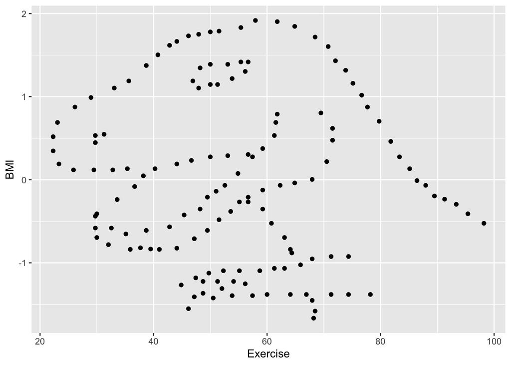

```r
ggplot(exercise_data,
       aes(x = Exercise, y = BMI)) +
       geom_point()
```

What do you see?

**Answer:** I see a dinosaur with the scatterplot instead of the expected negative correlation style relationship between Exercise and BMI.

Yes, I tricked you. This is an example that comes from [Alberto Cairo](https://twitter.com/AlbertoCairo). It reinforces how important it is to look at your data.

Looking at presumed relationships without visualizing your data is a dangerous task, as this [experiment](https://genomebiology.biomedcentral.com/articles/10.1186/s13059-020-02133-w#article-info) neatly shows. Always look at your data; you don’t want any Gorillas or Dinosaurs in your analyses.

## Question 2

Many of the ideas in these chapters were already familiar to you but this is an opportunity to go deeper and really understand how the machinery of ggplot works. We are going to be working with a dataset from the `causact` package that contains information about the Human Development Index (HDI) and Corruption Index (CPI) for different countries in 2017. Begin by installing the package running `install.packages("causact")`. Load the package and glimpse the dataset:

```r
#|message: false
library(causact)
glimpse(corruptDF)
```

```
Rows: 174
Columns: 7
$ country     <chr> "Afghanistan", "Albania", "Algeria", "Angola", "Argentina"…
$ region      <chr> "Asia Pacific", "East EU Cemt Asia", "MENA", "SSA", "Ameri…
$ countryCode <chr> "AFG", "ALB", "DZA", "AGO", "ARG", "ARM", "AUS", "AUT", "A…
$ regionCode  <chr> "AP", "ECA", "MENA", "SSA", "AME", "ECA", "AP", "WE/EU", "…
$ population  <int> 35530081, 2873457, 41318142, 29784193, 44271041, 2930450, …
$ CPI2017     <int> 15, 38, 33, 19, 39, 35, 77, 75, 31, 65, 36, 28, 68, 44, 75…
$ HDI2017     <dbl> 0.498, 0.785, 0.754, 0.581, 0.825, 0.755, 0.939, 0.908, 0.…
```

```
## Rows: 174
## Columns: 7
## $ country     <chr> "Afghanistan", "Albania", "Algeria", "Angola", "Argentina"…
## $ region      <chr> "Asia Pacific", "East EU Cemt Asia", "MENA", "SSA", "Ameri…
## $ countryCode <chr> "AFG", "ALB", "DZA", "AGO", "ARG", "ARM", "AUS", "AUT", "A…
## $ regionCode  <chr> "AP", "ECA", "MENA", "SSA", "AME", "ECA", "AP", "WE/EU", "…
## $ population  <int> 35530081, 2873457, 41318142, 29784193, 44271041, 2930450, …
## $ CPI2017     <int> 15, 38, 33, 19, 39, 35, 77, 75, 31, 65, 36, 28, 68, 44, 75…
## $ HDI2017     <dbl> 0.498, 0.785, 0.754, 0.581, 0.825, 0.755, 0.939, 0.908, 0.…
```

Before we move forward, we want to know what these variables capture. Run `?corruptDF` and tell me in your own words what `CPI2017` and `HDI2017` capture.

```r
?corruptDF
```

**Answer:** In my own words, the `CPI2017` variable identifies the levels of public sector corruption on scale from 0-100 in a country or territory occurring in 2017. A 0 means that the country or territory is highly corrupt, and a 100 means those areas looked upon as extremely clean. The `HDI2017` variable measures the successes in the fundamental areas of human development across countries in 2017. The HDI is created by an average of the longevity, education, and income of the nation, and it is unweighted.

## Question 3

Here, we are interested in the relationship between the HDI and CPI.

Begin by making a scatter plot that shows the relationship between these two variables. Describe the relationship that you see.

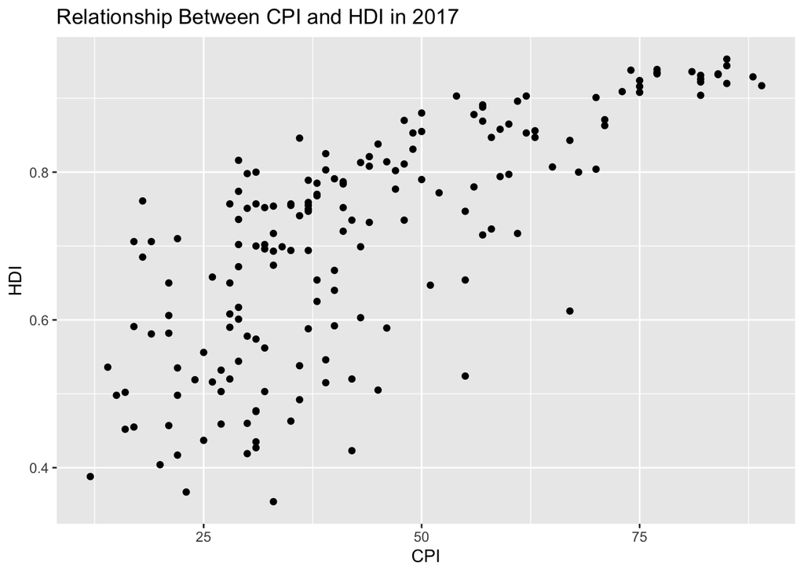

```r
ggplot(corruptDF, aes(x = CPI2017, y = HDI2017)) +
  geom_point() +
  labs(x = "CPI", y = "HDI", title = "Relationship Between CPI and HDI in 2017")
```

**Answer:** There is a positive correlation between the HDI and CPI in the year 2017. As the HDI scores increase, the CPI scores increase as well. This means that the cleaner the countries are - meaning that they have low corruption levels - the higher amount of human development they will have in their area.

## Question 4

Add a layer that captures the overall relationship between these two variables using `geom_smooth()`. Use both the `lm` and `gam` methods. What are the differences? Which one do you prefer?

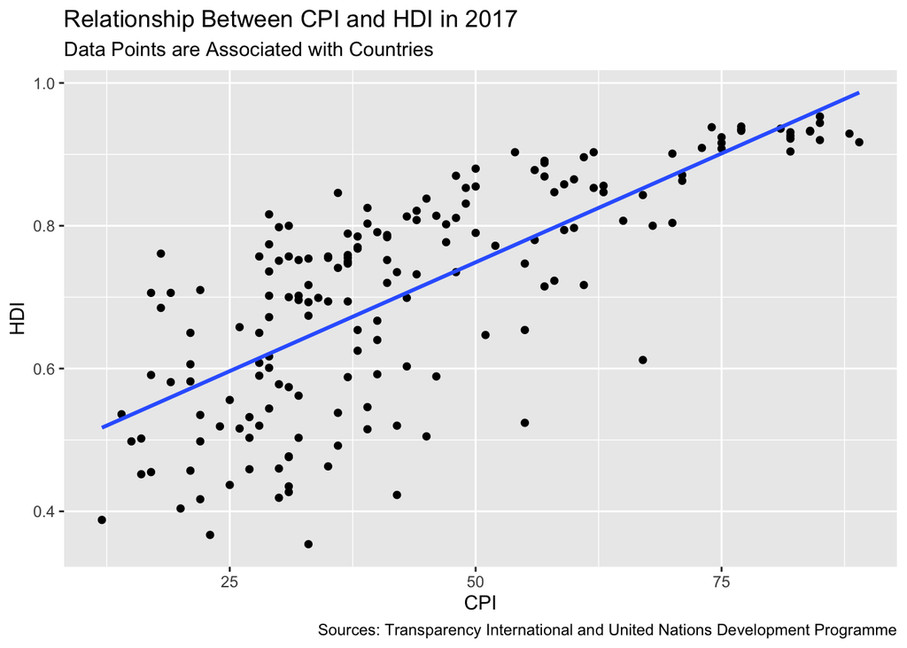

```r
ggplot(corruptDF, aes(x = CPI2017, y = HDI2017)) +
  geom_point() +
  geom_smooth(method = "lm", se = FALSE) +
  labs(x = "CPI", y = "HDI", title = "Relationship Between CPI and HDI in 2017", subtitle = "Data Points are Associated with Countries", caption = "Sources: Transparency International and United Nations Development Programme")
```

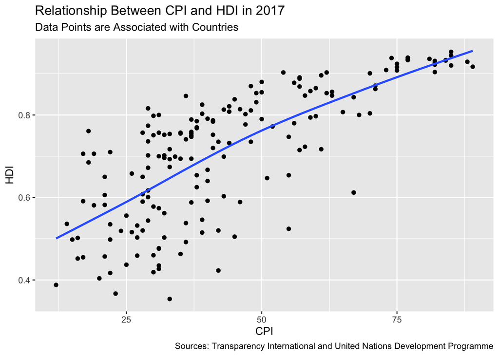

```r
ggplot(corruptDF, aes(x = CPI2017, y = HDI2017)) +
  geom_point() +
  geom_smooth(method = "gam", se = FALSE) +
  labs(x = "CPI", y = "HDI", title = "Relationship Between CPI and HDI in 2017", subtitle = "Data Points are Associated with Countries", caption = "Sources: Transparency International and United Nations Development Programme")
```

**Answer:** The differences between the models is that the linear model and is linear and the generalized additive model curves based on the data. This differences means the linear model describes a linear relationship, while the generalized additive model is displaying a non-linear relationship with the data. I prefer the linear model as it is clearer and is an easier tool to interpret the data.

## Question 5

It would be interesting to explore if this relationship varies by region. Add a fill and color aesthetic to the graph so that the lines and points are grouped by the variable `region`.

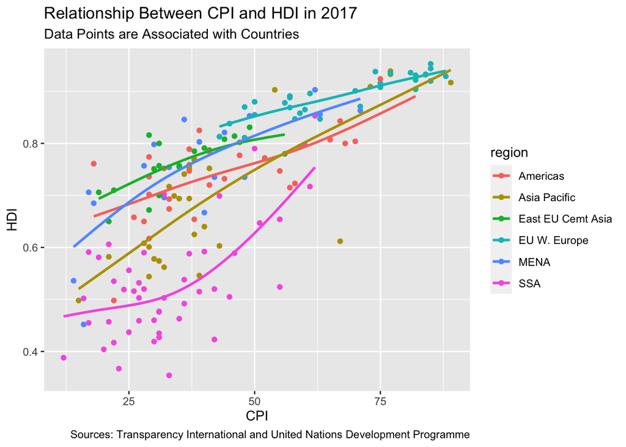

```r
ggplot(corruptDF, aes(x = CPI2017, y = HDI2017, fill = region, color = region)) +
  geom_point() +
  geom_smooth(method = "gam", se = FALSE) +
    labs(x = "CPI", y = "HDI", title = "Relationship Between CPI and HDI in 2017", subtitle = "Data Points are Associated with Countries", caption = "Sources: Transparency International and United Nations Development Programme")
```

What do you see? Are patterns clear or is the graph too cluttered? What would be another way to get these trends by region but in a way to would be more legible?

**Answer:** I see that there are varying levels of strength in the positive relationship between CPI and HDI levels by regions in the year 2017. Regions like the Americas has a much stronger positive linear relationship between the two values than Sub-Saharan Africa (SSA). The patterns are not clear because the graph is extremely cluttered. to see these trends in a better way, I suggest using `facet_wrap()` by `region` to make them more legible.

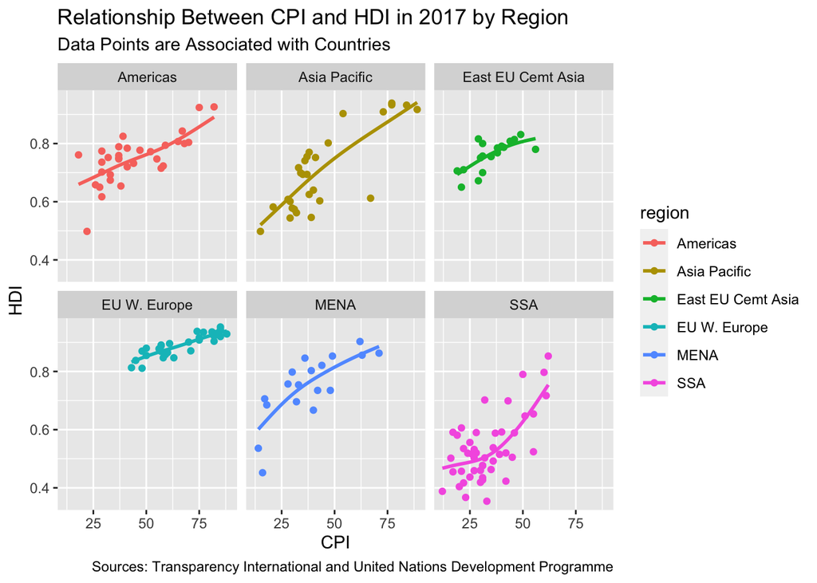

```r
ggplot(corruptDF, aes(x = CPI2017, y = HDI2017, fill = region, color = region)) +
  geom_point() +
  geom_smooth(method = "gam", se = FALSE) +
  labs(x = "CPI", y = "HDI", title = "Relationship Between CPI and HDI in 2017 by Region", subtitle = "Data Points are Associated with Countries", caption = "Sources: Transparency International and United Nations Development Programme") +
  facet_wrap(~region)
```

> Hint: think facets

## Question 6

Using one of the options that Healy gives you in the `where to go next` section of chapter 3, reverse the scale of the x-axis.

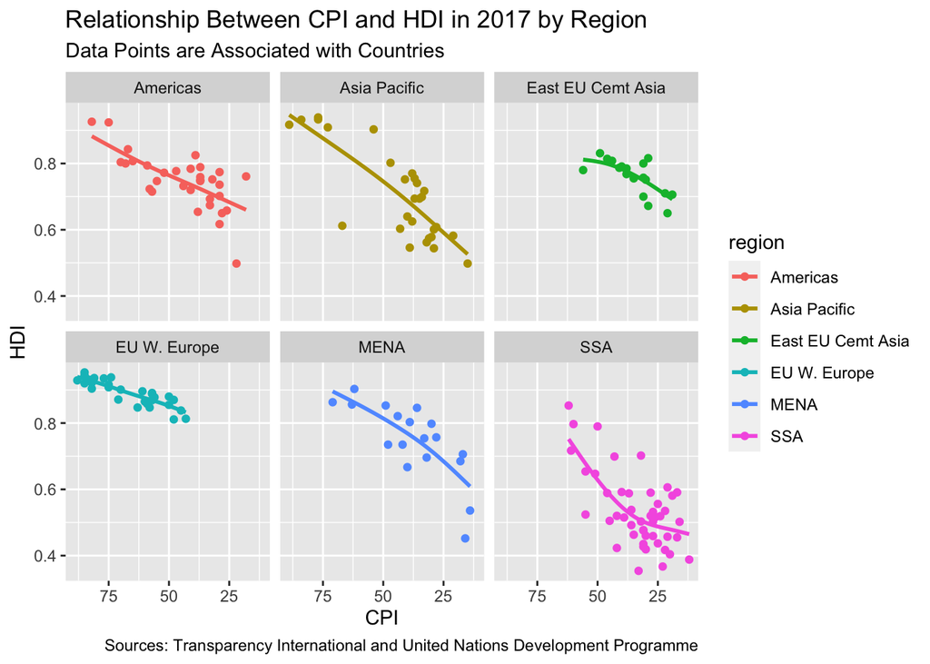

```r
ggplot(corruptDF, aes(x = CPI2017, y = HDI2017, fill = region, color = region)) +
  geom_point() +
  geom_smooth(method = "gam", se = FALSE) +
  facet_wrap(~region) +
 labs(x = "CPI", y = "HDI", title = "Relationship Between CPI and HDI in 2017 by Region", subtitle = "Data Points are Associated with Countries", caption = "Sources: Transparency International and United Nations Development Programme") +
  scale_x_reverse()
```

**Answer:** I used the `scale_x_reverse` function because it reversed the scale of the x-axis and shows that there is lower human development (lower HDI) if there is a high amount of corruption (lower CPI).

## Question 7

Add a title and a subtitle to the plot. Also add a caption, where you let me know where the data comes from.

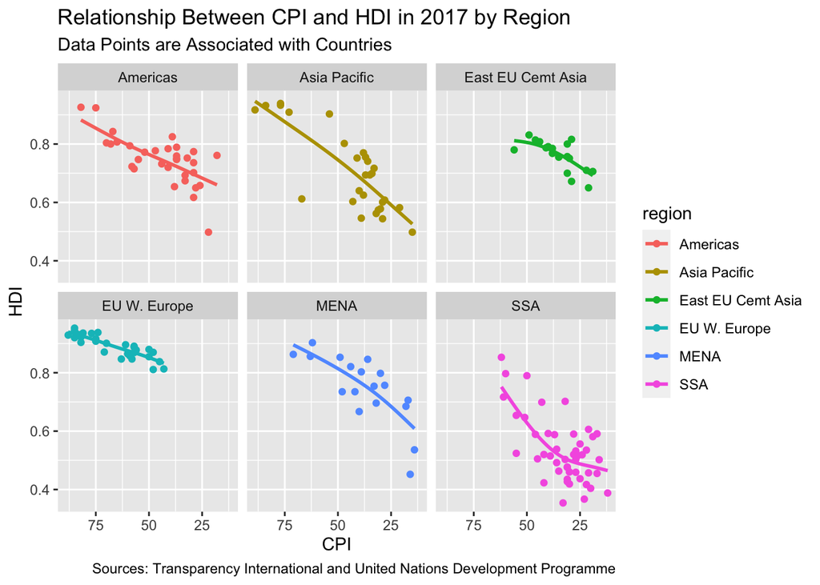

```r
ggplot(corruptDF, aes(x = CPI2017, y = HDI2017, fill = region, color = region)) +
  geom_point() +
  geom_smooth(method = "gam", se = FALSE) +
  facet_wrap(~region) +
  labs(x = "CPI", y = "HDI", title = "Relationship Between CPI and HDI in 2017 by Region", subtitle = "Data Points are Associated with Countries", caption = "Sources: Transparency International and United Nations Development Programme") +
  scale_x_reverse()
```

## Question 8

Now, that your plot about the relationship between the Human Development Index and the Corruption Perception Index is informative and sleek, you want to save it. Imagine it you want to print in a poster or send it to a supervisor. Show me code that would save the plot.

```r
ggsave(filename = "CPI_HDI_Scatterplot_2017.pdf")
```